# Visualização de Dados: R, Python e Julia

Gustavo Coimbra de Souza Teixeira, Julia Folgueral, Maria Eduarda Villéla Silva, Nicole de Barros Silva

# Introdução

- Comparação entre diferentes linguagens para visualização de dados;
- Foco em gráficos;
- Banco de dados usado: Análise de desempenho de funcionários para RH  
  O banco usado está disponível [aqui](https://docs.google.com/spreadsheets/d/1PetYZnhqiE3zUcjU0_bo5kt4_WZb0vsV/edit?usp=sharing&ouid=105910103995890526581&rtpof=true&sd=true).

## Sobre o Banco de Dados

O conjunto de dados apresenta informações dos funcionários de uma empresa, incluindo:

- Departamento
- Formação acadêmica
- Gênero
- Canal de recrutamento
- Nº de treinamentos
- Idade
- Avaliação anterior
- Tempo de serviço
- Indicadores-chave de desempenho(KPI’s) atingidos
- Média de treinamentos

## Critérios para comparação entre linguagens

Para realizar uma comparação justa entre R, Python e Julia foram considerados os seguintes critérios:

- Tempo de execução do gráfico;
- Memória usada para plotar o gráfico;
- Quantidade de linhas de código.

# Linguagem R

## Boxplot

Pontuação em treinamentos por formação acadêmica

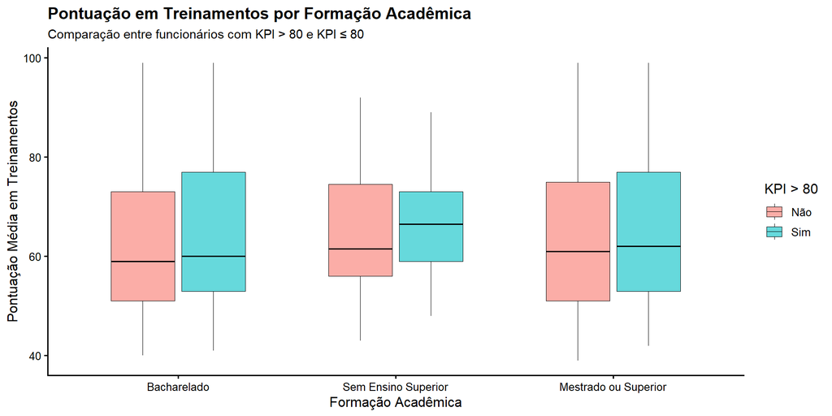

```r
library(ggplot2)

ggplot(dados_corrigidos, aes(
  x = education,
  y = avg_training_score,
  fill = KPIs_met_more_than_80
)) +
  geom_boxplot(
    alpha = 0.6,
    width = 0.65,
    outlier.color = "red",
    color = "black",
    size = 0.3
  ) +
  labs(
    title = "Pontuação em Treinamentos por Formação Acadêmica",
    subtitle = "Comparação entre funcionários com KPI > 80 e KPI ≤ 80",
    x = "Formação Acadêmica",
    y = "Pontuação Média em Treinamentos",
    fill = "KPI > 80"
  ) +
  scale_fill_manual(values = c(
    "Não" = "#F8766D",
    "Sim" = "#00BFC4"
  )) +
  scale_x_discrete(labels = c(
    "Below Secondary" = "Sem Ensino Superior",
    "Bachelors" = "Bacharelado",
    "Masters & above" = "Mestrado ou Superior"
  )) +
  theme_classic(base_size = 12) +
  theme(
    plot.title = element_text(size = 14, face = "bold"),
    plot.subtitle = element_text(size = 11),
    axis.text.x = element_text(angle = 0, hjust = 0.5),
    legend.position = "right"
  )
```

## Boxplot usando ggthemes()

Tema: FiveThirtyEight (famoso site norte-americano de jornalismo de dados).

Estilo clean, jornalístico e moderno aos gráficos.

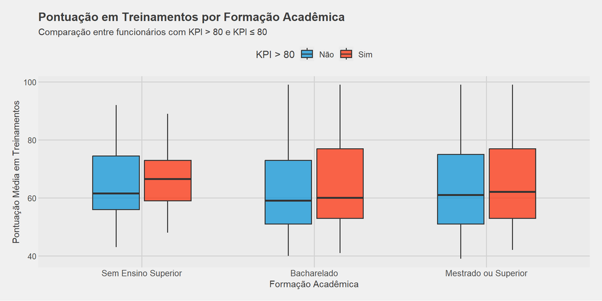

```r
# Converte "education" para fator e ordena o eixo x
dados_corrigidos$education <- factor(
  dados_corrigidos$education,
  levels = c("Below Secondary", "Bachelors", "Masters & above")
)

# Gráfico
ggplot(dados_corrigidos, aes(
  x = education,
  y = avg_training_score,
  fill = KPIs_met_more_than_80
)) +
  geom_boxplot(
    alpha = 0.7,
    width = 0.6,
    outlier.color = "red"
  ) +


  scale_fill_fivethirtyeight() + # Paleta de cores do estilo FiveThirtyEight.


  theme_fivethirtyeight() + # Define o tema do FiveThirtyEight.

  labs(
    title = "Pontuação em Treinamentos por Formação Acadêmica",
    subtitle = "Comparação entre funcionários com KPI > 80 e KPI ≤ 80",
    x = "Formação Acadêmica",
    y = "Pontuação Média em Treinamentos",
    fill = "KPI > 80"
  ) +
  scale_x_discrete(labels = c(
    "Below Secondary" = "Sem Ensino Superior",
    "Bachelors" = "Bacharelado",
    "Masters & above" = "Mestrado ou Superior"
  )) +
  theme(
    legend.position = "top",
    plot.title = element_text(size = 14),
    plot.subtitle = element_text(size = 11),
    axis.text.x = element_text(size = 10),
    axis.title = element_text(size = 11)
  )
```

## Histograma

Distribuição das idades dos funcionários

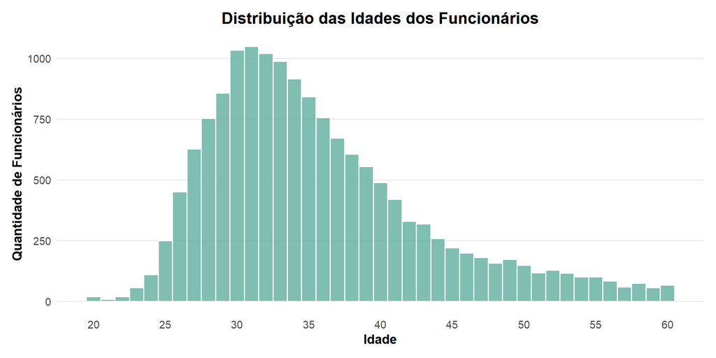

```r
# Gráfico
dados_corrigidos %>%
  ggplot(aes(x = age)) +
  geom_histogram(
    binwidth = 1,
    fill = "#69b3a2",
    color = "white",
    alpha = 0.85
  ) +
  ggtitle("Distribuição das Idades dos Funcionários") +
  labs(
    x = "Idade",
    y = "Quantidade de Funcionários"
  ) +
  theme_minimal(base_size = 13) +
  theme(
    plot.title = element_text(size = 16, face = "bold", hjust = 0.5),
    axis.text = element_text(size = 11),
    axis.title = element_text(size = 13, face = "bold"),
    panel.grid.minor = element_blank(),
    panel.grid.major.x = element_blank(),
    plot.margin = margin(12, 12, 12, 12)
  ) +
  scale_x_continuous(
    breaks = seq(min(dados_corrigidos$age), max(dados_corrigidos$age), 5)
  )
```

### Histograma usando o ggthemes

Tema: Stata (software profissional de estatística).

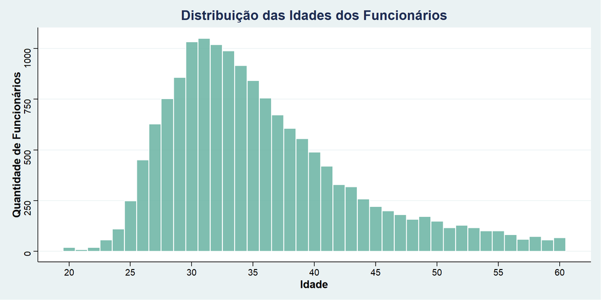

```r
# Gráfico
dados_corrigidos %>%
  ggplot(aes(x = age)) +
  geom_histogram(
    binwidth = 1,
    fill = "#69b3a2",
    color = "white",
    alpha = 0.85
  ) +
  ggtitle("Distribuição das Idades dos Funcionários") +
  labs(
    x = "Idade",
    y = "Quantidade de Funcionários"
  ) +
  theme_stata(base_size = 13) + # Tema Stata (pacote ggthemes)
  theme(
    plot.title = element_text(size = 16, face = "bold", hjust = 0.5),
    axis.text = element_text(size = 11),
    axis.title = element_text(size = 13, face = "bold"),
    panel.grid.minor = element_blank(),
    plot.margin = margin(12, 12, 12, 12)
  ) +
  scale_x_continuous(
    breaks = seq(min(dados_corrigidos$age), max(dados_corrigidos$age), 5)
  )
```

## Gráfico de linhas facetado

Média de treinamentos ao longo do tempo de serviço

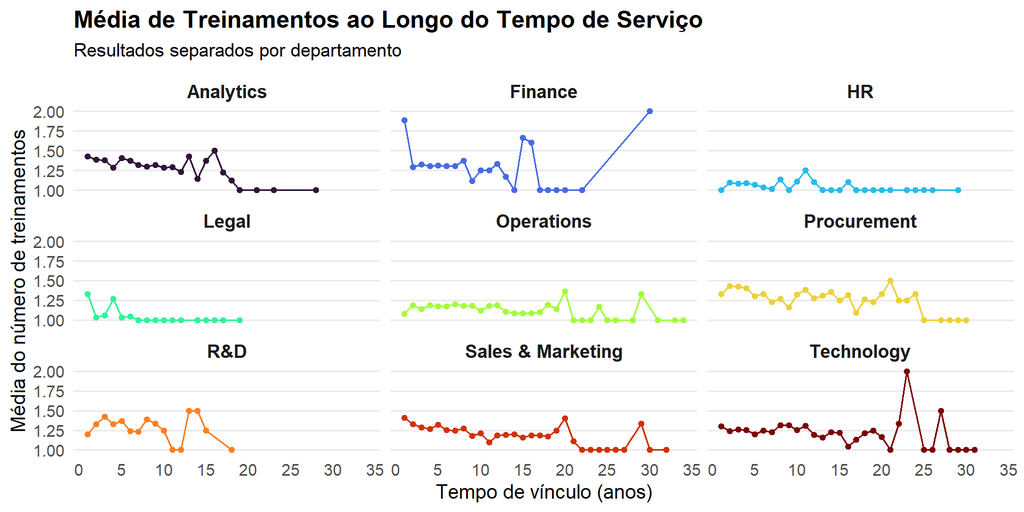

```r
# Preparação dos dados
dados_linha2 <- dados_corrigidos %>%
  group_by(department, length_of_service) %>%
  summarise(media_treinamentos = mean(no_of_trainings), .groups = "drop") %>%
  drop_na()

# Gráfico de linhas facetado
ggplot(dados_linha2, aes(x = length_of_service, y = media_treinamentos, color = department)) +
  geom_line(size = 0.7) +
  geom_point(size = 1.5) +
  facet_wrap(~ department) +
  scale_color_viridis_d(option = "turbo") + # Paleta viridis
  scale_x_continuous(breaks = scales::pretty_breaks(n = 8)) +
  scale_y_continuous(limits = c(1, 2)) +   # mesmo intervalo em todas as facetas
  labs(
    title = "Média de Treinamentos ao Longo do Tempo de Serviço",
    subtitle = "Resultados separados por departamento",
    x = "Tempo de vínculo (anos)",
    y = "Média do número de treinamentos",
    color = "Departamento"
  ) +
  theme_minimal(base_size = 14) +
  theme(
    legend.position = "none",
    strip.text = element_text(face = "bold", size = 13),
    plot.title = element_text(face = "bold", size = 17),
    plot.subtitle = element_text(size = 13, margin = margin(b = 10)),
    panel.grid.minor = element_blank(),
    panel.grid.major.x = element_blank()
  )
```

## Gráfico de barras usando o ggthemes

Tema: The Economist (replica o estilo visual dos gráficos publicados pela revista The Economist)

Design limpo, profissional e sofisticado.

Distribuição de funcionários por gênero e departamento

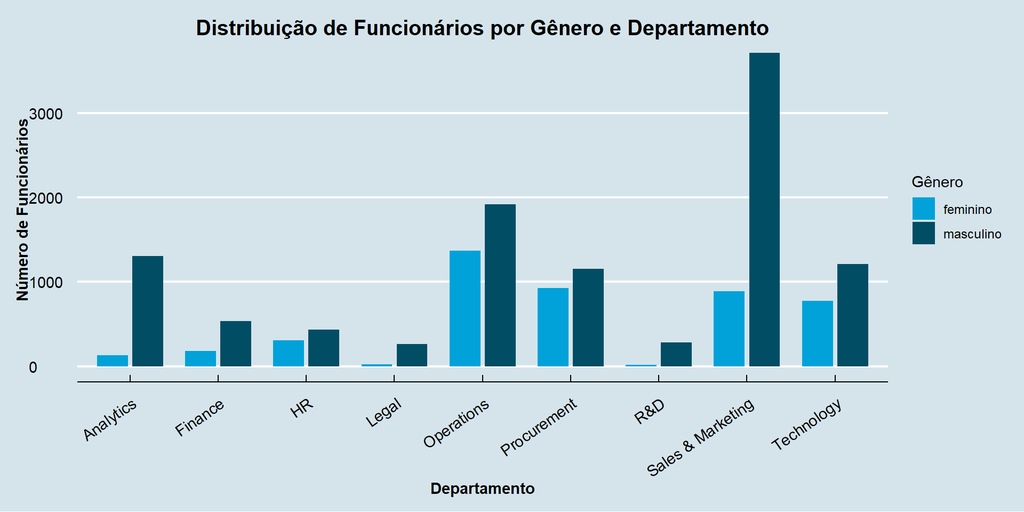

```r
# Grafico
ggplot(dados_corrigidos, aes(x = department, fill = gender)) +
  geom_bar(position = position_dodge(width = 0.8), width = 0.7) +
  labs(
    title = "Distribuição de Funcionários por Gênero e Departamento",
    x = "Departamento",
    y = "Número de Funcionários",
    fill = "Gênero"
  ) +

  # Paleta e tema Economist (ggthemes)
  scale_fill_economist() +
  theme_economist() +

  # Ajustes estéticos
  theme(
    plot.title = element_text(face = "bold", size = 15, hjust = 0.5),
    plot.subtitle = element_text(size = 10, hjust = 0.5, margin = margin(b = 10)),
    axis.text.x = element_text(angle = 35, vjust = 1, hjust = 1),
    legend.position = "right",
    legend.text = element_text(size = 9),
    legend.title = element_text(size = 11),
    panel.grid.major.x = element_blank(),
    panel.grid.minor = element_blank(),
    axis.title = element_text(face = "bold")
  )
```

# Python

## Boxplot

Pontuação em treinamentos por formação acadêmica

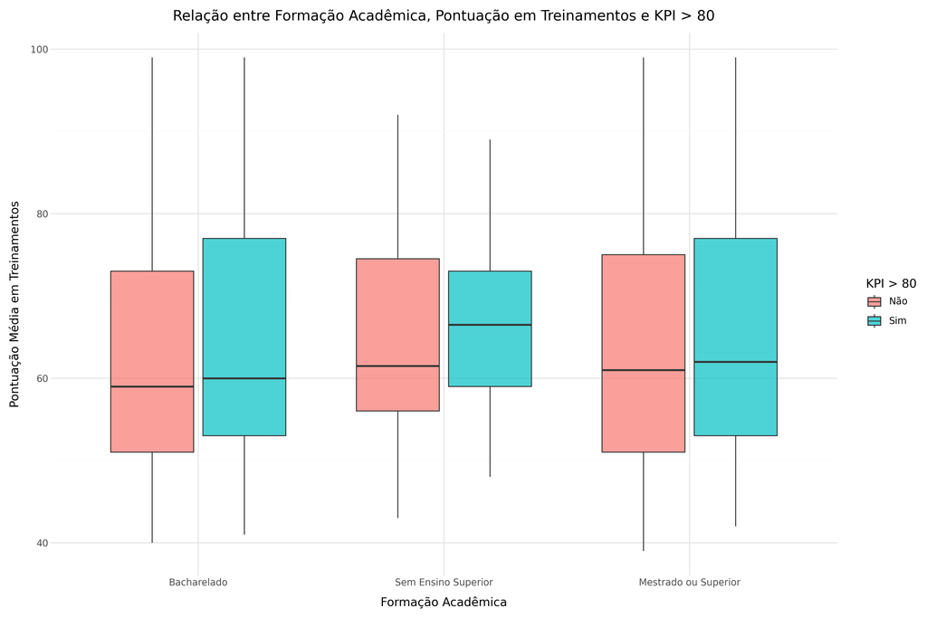

```python
from plotnine import (
    ggplot, aes, geom_boxplot, labs, theme_minimal,
    scale_fill_manual, scale_x_discrete, theme, element_text
)


# Grafico
plot1_python = ((
    ggplot(dados_corrigidos, aes(
        x='education',
        y='avg_training_score',
        fill='KPIs_met_more_than_80'
    ))
    + geom_boxplot(alpha=0.7, outlier_color="red")
    + labs(
        title="Relação entre Formação Acadêmica, Pontuação em Treinamentos e KPI > 80",
        x="Formação Acadêmica",
        y="Pontuação Média em Treinamentos",
        fill="KPI > 80"
    )
    + scale_fill_manual(values={
        "Não": "#F8766D",
        "Sim": "#00BFC4"
    })
    + scale_x_discrete(labels={
        "Below Secondary": "Sem Ensino Superior",
        "Bachelors": "Bacharelado",
        "Masters & above": "Mestrado ou Superior"
    })
    + theme_minimal()
    + theme(
        plot_title=element_text(size=12, weight="bold"),
        axis_text_x=element_text(angle=0, ha="center")
    )
)
)

plot1_python.save("plot1_python.png", width=12, height=8, dpi=300)
```

## Histograma

Distribuição das idades dos funcionários

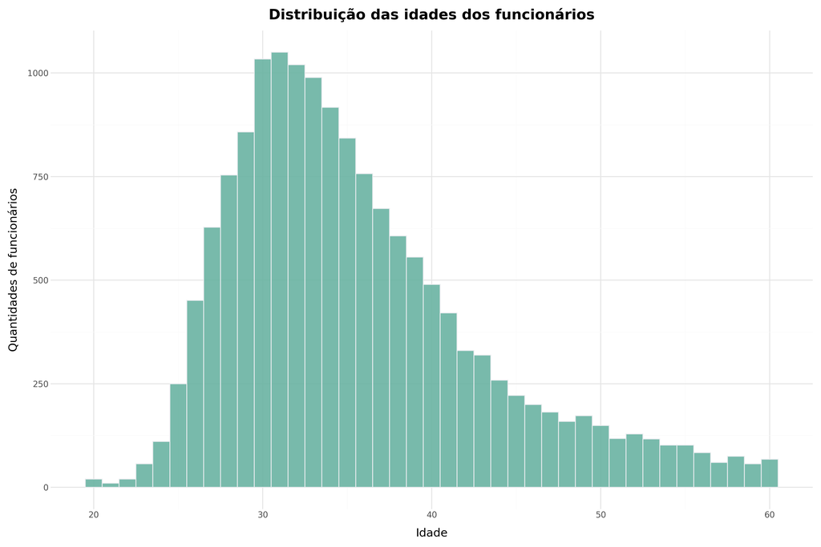

```python
from plotnine import ggplot, aes, geom_histogram, labs, theme_minimal, theme, element_text

# Gráfico
plot4_python = (
    ggplot(dados_corrigidos, aes(x="age"))
    + geom_histogram(
        binwidth=1,
        fill="#69b3a2",
        color="#e9ecef",
        alpha=0.9
    )
    + labs(
        title="Distribuição das idades dos funcionários",
        x="Idade",
        y="Quantidades de funcionários"
    )
    + theme_minimal()
    + theme(
        plot_title=element_text(size=15, weight="bold"),
        axis_title=element_text(size=12)
    )
)

plot4_python.save("plot4_python.png", width=12, height=8, dpi=300)
```

## Grafico de linhas facetado

Média de treinamentos ao longo do tempo de serviço

Pacote “seaborn”: facilita a criação de um gráfico facetado.

```python
import pandas as pd
import matplotlib.pyplot as plt
import seaborn as sns

#Preparação dos dados - Criar tabela POR DEPARTAMENTO e tempo de serviço
dados_linha2 = (dados_corrigidos
                .groupby(['department', 'length_of_service'])
                .agg(media_treinamentos=('no_of_trainings', 'mean'))
                .reset_index())

# Configurar estilo
sns.set_style("whitegrid")
plt.rcParams['font.size'] = 14

# Gráfico
g = sns.FacetGrid(
    dados_linha2,
    col='department',
    col_wrap=3,
    sharey=True,        # Mesma escala em todas as facetas
    height=4,
    aspect=1.2
)

g.map(
    plt.plot,
    'length_of_service',
    'media_treinamentos',
    color='#2C7BB6',
    linewidth=1.2,
    marker='o',
    markersize=5
)

g.fig.subplots_adjust(hspace=0.35, wspace=0.25)

# Títulos
g.set_axis_labels('Tempo de vínculo empregatício', 'Média do número de treinamentos')
g.set_titles(col_template="{col_name}", size=12, weight='bold')
g.fig.suptitle('Tempo de Vínculo x Média de Treinamentos por Departamento',
               fontsize=16, fontweight='bold', y=1.05)

plt.tight_layout()

# Salvar figura
plt.savefig('plot6_dep_python.png', dpi=300, bbox_inches='tight')

plt.show()
```

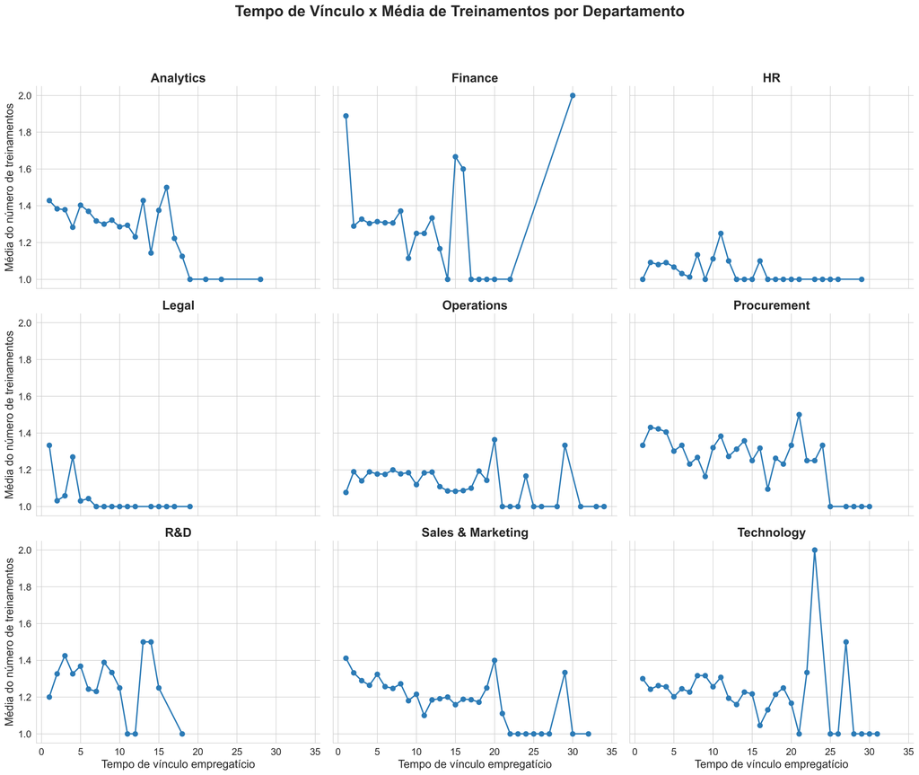

## Gráfico de barras

Quantidade de funcionários por genêro em cada departamento

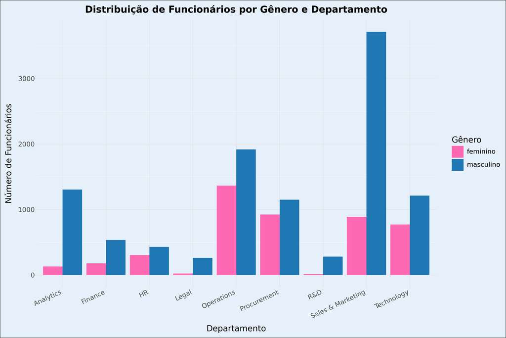

```python
import time
import psutil
import os
from plotnine import (
    ggplot, aes, geom_bar, labs, theme_minimal,
    theme, element_rect, element_text, scale_fill_manual
)

# Gráfico
plot7_python = (
    ggplot(dados_corrigidos, aes(x='department', fill='gender'))
    + geom_bar(position='dodge')
    + labs(
        title="Distribuição de Funcionários por Gênero e Departamento",
        x="Departamento",
        y="Número de Funcionários",
        fill="Gênero"
    )
    + scale_fill_manual(
        values={
            "masculino": "#1f77b4",     # azul
            "feminino": "#ff69b4"   # rosa
        }
    )
    + theme_minimal(base_size=14)
    + theme(
        panel_background=element_rect(fill="#E6F0FA", color=None),
        plot_background=element_rect(fill="#E6F0FA", color=None),
        axis_text_x=element_text(angle=25, ha="right"),
        plot_title=element_text(weight="bold", size=16)
    )
)

# Salvar o gráfico
plot7_python.save("plot7_python.png", width=12, height=8, dpi=300)
```

# Julia

## Boxplot

```julia
using DataFrames
using StatsPlots
using Plots


resultado = @timed begin
    plot1_julia = @df df groupedboxplot(
        :education_pt,
        :avg_training_score,
        group = :KPIs_met_more_than_80,
        fillalpha = 0.7,
        outliers = true,
        outliercolor = :red,
        palette = ["#F8766D", "#00BFC4"],
        title = "Relação entre Formação Acadêmica, Pontuação em Treinamentos e KPI > 80",
        xlabel = "Formação Acadêmica",
        ylabel = "Pontuação Média em Treinamentos",
        label = ["Não" "Sim"],
        legend = :topright,
        size = (1200, 800),
        titlefontsize = 12,
        left_margin = 10Plots.mm,
        bottom_margin = 5Plots.mm
    )

    Plots.savefig(plot1_julia, "plot1_julia.png")
    plot1_julia
end

# Exibir o gráfico
display(plot1_julia)
```

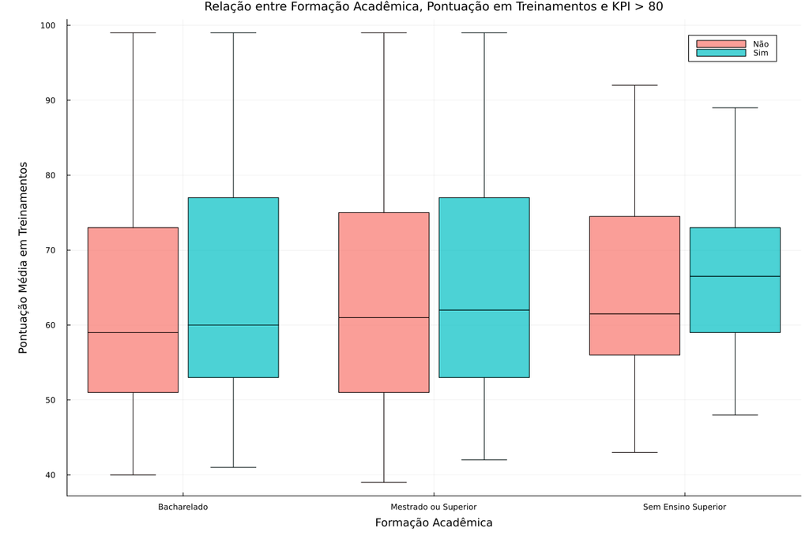

## Histograma

Distribuição das idades dos funcionários

```julia
#using DataFrames
#using StatsPlots
#using Plots

# Converter para DataFrame
df = DataFrame(dados_corrigidos)

# Criar histograma
resultado = @timed begin
plot4_julia = @df df Plots.histogram(
    :age,
    bins = minimum(:age):1:maximum(:age),
    fillcolor = "#69b3a2",
    linecolor = "#e9ecef",
    fillalpha = 0.9,
    title = "Distribuição das idades dos funcionários",
    xlabel = "Idade",
    ylabel = "Quantidades de funcionários",
    legend = false,
    size = (1200, 800),
    titlefontsize = 15,
    #titlefont = font(15, "bold"),
    guidefontsize = 12,
    left_margin = 10Plots.mm,
    bottom_margin = 5Plots.mm
)

Plots.savefig(plot4_julia, "plot4_julia.png")
    plot4_julia
end


# Exibir o gráfico
display(plot4_julia)
```

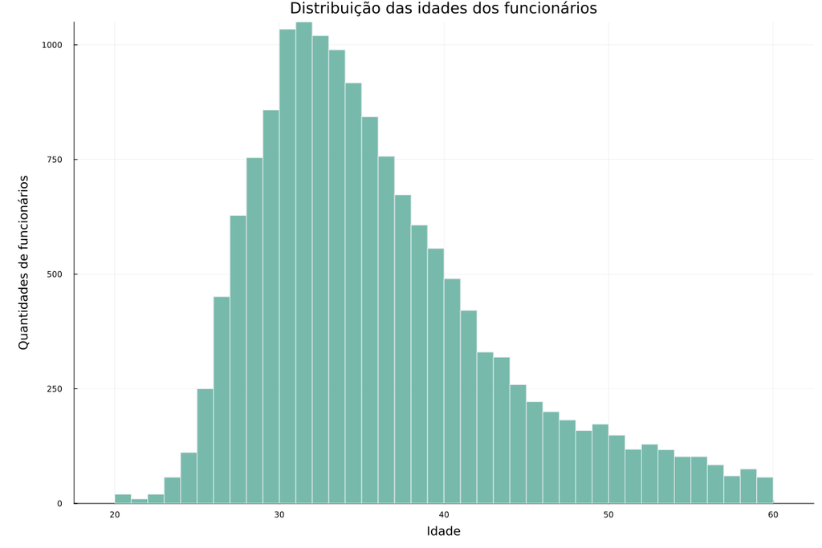

## Gráfico de linhas facetado

Média de treinamentos ao longo do tempo de serviço - separado por área

```julia
# Converter para DataFrame
df = DataFrame(dados_corrigidos)

# Preparação dos dados - Criar tabela agregada por departamento e tempo de serviço
dados_linha2 = combine(groupby(df, [:department, :length_of_service]),
                       :no_of_trainings => mean => :media_treinamentos)

# Ordenar por departamento e tempo de serviço
sort!(dados_linha2, [:department, :length_of_service])

# Obter departamentos únicos
departments = sort(unique(dados_linha2.department))
n_dept = length(departments)

# Fixar a mesma escala para todas as facetas
x_min, x_max = extrema(dados_linha2.length_of_service)
y_min, y_max = extrema(dados_linha2.media_treinamentos)

# Criar função para gerar os gráficos de linhas
function create_line_plot(dept_name, dados_linha2)
    df_dept = filter(row -> row.department == dept_name, dados_linha2)
    return plot(
        df_dept.length_of_service,
        df_dept.media_treinamentos,
        linewidth = 1.5,
        linecolor = "#2C7BB6",
        marker = :circle,
        markersize = 3,
        markercolor = "#2C7BB6",
        markerstrokewidth = 0,
        xlabel = "Tempo de vínculo",
        ylabel = "Média de treinamentos",
        title = dept_name,
        legend = false,
        titlefontsize = 12,
        guidefontsize = 10,
        tickfontsize = 9,
        grid = true,
        gridstyle = :dot,
        gridalpha = 0.3,
        xlim = (x_min, x_max),
        ylim = (y_min, y_max)
    )
end

# Plotar o gráfico
resultado = @timed begin
    plots_list = [create_line_plot(dept, dados_linha2) for dept in departments]

    n_rows = Int(ceil(n_dept / 3))

    plot6f_julia = plot(
        plots_list...,
        layout = (n_rows, 3),
        size = (1400, 1000),
        left_margin = 10Plots.mm,
        bottom_margin = 10Plots.mm
    )

    plot!(plot6f_julia,
          plot_title = "Tempo de Vínculo x Média de Treinamentos por Departamento",
          plot_titlefontsize = 16)

    Plots.savefig(plot6f_julia, "plot6f_julia.png")

    plot6f_julia
end


display(plot6f_julia)
```

```
15421×13 DataFrame
   Row │ employee_id  department         region     education        gender    ⋯
       │ Float64      String             String     String           String    ⋯
───────┼────────────────────────────────────────────────────────────────────────
     1 │     74430.0  HR                 region_4   Bachelors        feminino  ⋯
     2 │     72255.0  Sales & Marketing  region_13  Bachelors        masculino
     3 │     38562.0  Procurement        region_2   Bachelors        feminino
     4 │     64486.0  Finance            region_29  Bachelors        masculino
     5 │     46232.0  Procurement        region_7   Bachelors        masculino ⋯
     6 │     54542.0  Finance            region_2   Bachelors        masculino
     7 │     67269.0  Analytics          region_22  Bachelors        masculino
     8 │     66174.0  Technology         region_7   Masters & above  masculino
   ⋮   │      ⋮               ⋮              ⋮             ⋮             ⋮     ⋱
 15415 │     19281.0  Procurement        region_17  Bachelors        feminino  ⋯
 15416 │     38568.0  Sales & Marketing  region_24  Bachelors        masculino
 15417 │     54192.0  HR                 region_22  Below Secondary  masculino
 15418 │     57239.0  Sales & Marketing  region_31  Bachelors        masculino
 15419 │     73858.0  Sales & Marketing  region_25  Bachelors        masculino ⋯
 15420 │     64573.0  Technology         region_7   Bachelors        feminino
 15421 │     49584.0  HR                 region_7   Bachelors        masculino
                                                8 columns and 15406 rows omitted
```

```
223×3 DataFrame
 Row │ department         length_of_service  media_treinamentos
     │ String             Float64            Float64
─────┼──────────────────────────────────────────────────────────
   1 │ HR                               5.0             1.06667
   2 │ Sales & Marketing                4.0             1.26415
   3 │ Procurement                      9.0             1.16379
   4 │ Finance                          7.0             1.30682
   5 │ Procurement                      2.0             1.43038
   6 │ Finance                          3.0             1.3271
   7 │ Analytics                        3.0             1.3785
   8 │ Technology                      11.0             1.30769
  ⋮  │         ⋮                  ⋮                  ⋮
 217 │ Sales & Marketing               32.0             1.0
 218 │ R&D                             18.0             1.0
 219 │ Legal                           19.0             1.0
 220 │ Technology                      25.0             1.0
 221 │ Procurement                     29.0             1.0
 222 │ Procurement                     25.0             1.0
 223 │ Finance                         20.0             1.0
                                                208 rows omitted
```

```
223×3 DataFrame
 Row │ department  length_of_service  media_treinamentos
     │ String      Float64            Float64
─────┼───────────────────────────────────────────────────
   1 │ Analytics                 1.0             1.42857
   2 │ Analytics                 2.0             1.38308
   3 │ Analytics                 3.0             1.3785
   4 │ Analytics                 4.0             1.28261
   5 │ Analytics                 5.0             1.40323
   6 │ Analytics                 6.0             1.3697
   7 │ Analytics                 7.0             1.31757
   8 │ Analytics                 8.0             1.3
  ⋮  │     ⋮               ⋮                  ⋮
 217 │ Technology               25.0             1.0
 218 │ Technology               26.0             1.0
 219 │ Technology               27.0             1.5
 220 │ Technology               28.0             1.0
 221 │ Technology               29.0             1.0
 222 │ Technology               30.0             1.0
 223 │ Technology               31.0             1.0
                                         208 rows omitted
```

```
9-element Vector{String}:
 "Analytics"
 "Finance"
 "HR"
 "Legal"
 "Operations"
 "Procurement"
 "R&D"
 "Sales & Marketing"
 "Technology"
```

```
9
```

```
(1.0, 34.0)
```

```
(1.0, 2.0)
```

```
create_line_plot (generic function with 1 method)
```

```
(value = Plot{Plots.GRBackend() n=9}, time = 4.7665319, bytes = 166039823, gctime = 0.0677377, gcstats = Base.GC_Diff(166039823, 2857, 0, 3237320, 20, 3241, 67737700, 1, 0), lock_conflicts = 0, compile_time = 4.2304564, recompile_time = 0.4788766)
```

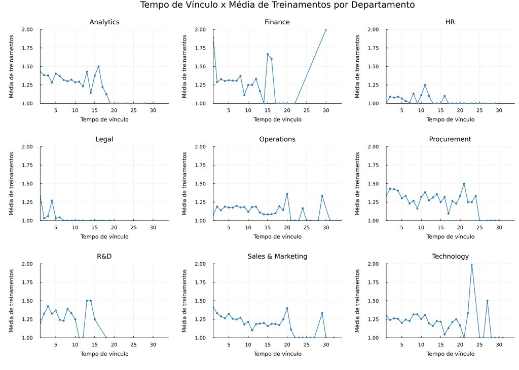

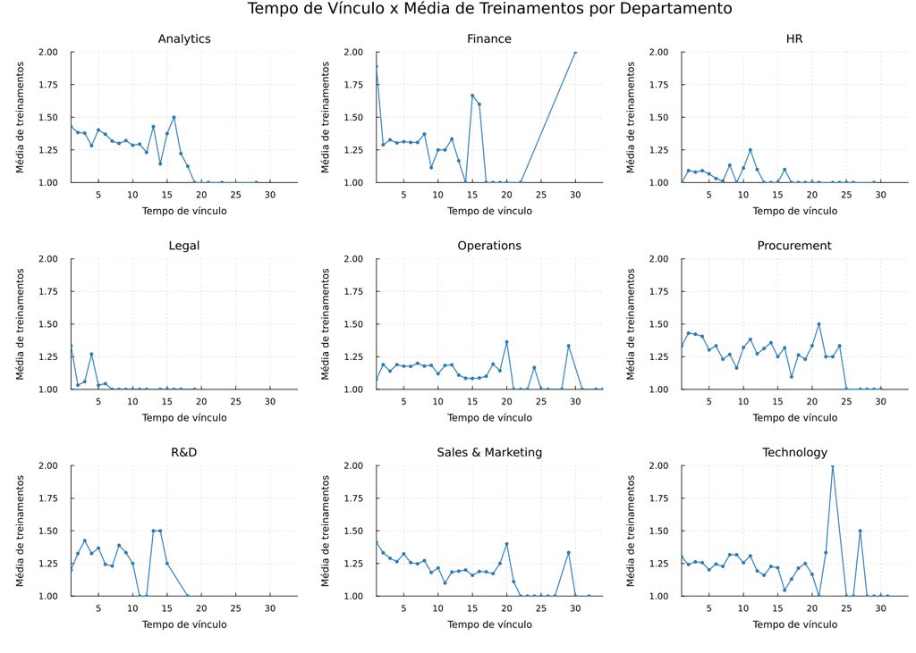

## Gráfico de barras

Quantidade de funcionários por genêro em cada departamento

```julia
# Converter para DataFrame
df = DataFrame(dados_corrigidos)

# Contar frequências por departmento e gênero
counts = combine(groupby(df, [:department, :gender]), nrow => :count)

# Preparação dos dados
counts_wide = unstack(counts, :department, :gender, :count, fill=0)

departments = counts_wide[:, 1]

genders = names(counts_wide)[2:end]

data_matrix = Matrix(counts_wide[:, 2:end])

# Criar gráfico
resultado = @timed begin
plot7_julia = groupedbar(
    data_matrix,
    bar_position = :dodge,
    xticks = (1:length(departments), departments),
    xrotation = 25,
    label = permutedims(genders),
    title = "Distribuição de Funcionários por Gênero e Departamento",
    xlabel = "Departamento",
    ylabel = "Número de Funcionários",
    legend = :topright,
    size = (1200, 800),
    titlefontsize = 16,
    guidefontsize = 14,
    tickfontsize = 12,
    legendfontsize = 12,
    left_margin = 10Plots.mm,
    bottom_margin = 10Plots.mm,
    background_color = "#E6F0FA",
    palette = ["#FF9999", "#6699CC"]
)

Plots.savefig(plot7_julia, "plot7_julia.png")
    plot7_julia
end


# Exibir o gráfico
display(plot7_julia)
```

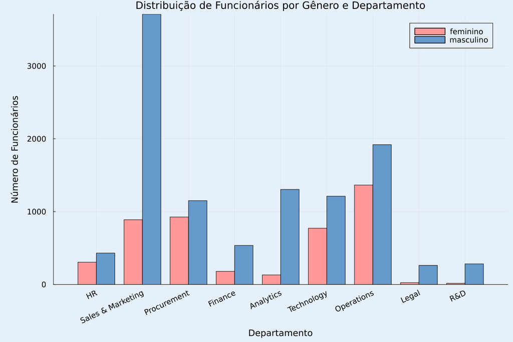

# Explorando Alternativas de Visualização em Julia

O principal pacote utilizado para gerar gráficos em Julia foi o **Plots.jl**, que apresentou bom desempenho e flexibilidade.  
Ainda assim, buscamos explorar outras opções para entender melhor o ecossistema de visualização da linguagem.

Entre os pacotes encontrados, o **UnicodePlots.jl** se destacou por suas vantagens únicas:

- Permite gerar gráficos diretamente no terminal, sem depender de janelas gráficas;
- É extremamente leve e rápido, ideal para máquinas com poucos recursos;
- Possui sintaxe simples e visualização imediata;

Essa diversidade mostra como Julia oferece diferentes soluções de visualização, cada uma adequada a necessidades específicas.

## Gráfico de Barras

```julia
resultado = @timed begin
    plot_barras_departamentos(departments, genders, data_matrix)
end
```

```
Departamento: HR
feminino   | ▇▇▇▇ 306
masculino  | ▇▇▇▇▇▇ 431


Departamento: Sales & Marketing
feminino   | ▇▇▇▇▇▇▇▇▇▇▇▇ 889
masculino  | ▇▇▇▇▇▇▇▇▇▇▇▇▇▇▇▇▇▇▇▇▇▇▇▇▇▇▇▇▇▇▇▇▇▇▇▇▇▇▇▇▇▇▇▇▇▇▇▇▇▇ 3712


Departamento: Procurement
feminino   | ▇▇▇▇▇▇▇▇▇▇▇▇ 926
masculino  | ▇▇▇▇▇▇▇▇▇▇▇▇▇▇▇▇ 1151


Departamento: Finance
feminino   | ▇▇ 180
masculino  | ▇▇▇▇▇▇▇ 536


Departamento: Analytics
feminino   | ▇▇ 131
masculino  | ▇▇▇▇▇▇▇▇▇▇▇▇▇▇▇▇▇▇ 1305


Departamento: Technology
feminino   | ▇▇▇▇▇▇▇▇▇▇ 772
masculino  | ▇▇▇▇▇▇▇▇▇▇▇▇▇▇▇▇ 1212


Departamento: Operations
feminino   | ▇▇▇▇▇▇▇▇▇▇▇▇▇▇▇▇▇▇ 1365
masculino  | ▇▇▇▇▇▇▇▇▇▇▇▇▇▇▇▇▇▇▇▇▇▇▇▇▇▇ 1919


Departamento: Legal
feminino   |  25
masculino  | ▇▇▇▇ 262


Departamento: R&D
feminino   |  16
masculino  | ▇▇▇▇ 283
```

```
(value = nothing, time = 0.3830499, bytes = 8127007, gctime = 0.0, gcstats = Base.GC_Diff(8127007, 137, 0, 157686, 0, 0, 0, 0, 0), lock_conflicts = 0, compile_time = 0.3508927, recompile_time = 0.0)
```

## Histograma

```julia
using Plots

# Define UnicodePlots como backend
unicodeplots()

# Criar histograma simples
ages = df.age
histogram(ages;
    nbins = 10,
    title = "Distribuição das idades dos funcionários",
    xlabel = "Idade",
    ylabel = "Quantidade de funcionários"
)
```

```
Plots.UnicodePlotsBackend()
```

```
                          ⠀Distribuição das idades dos funcionários⠀
                          ┌────────────────────────────────────────┐
                     5 010│⠀⠀⠀⠀⠀⠀⠀⠀⠀⠀⡏⠉⚬⠉⡇⠀⠀⠀⠀⠀⠀⠀⠀⠀⠀⠀⠀⠀⠀⠀⠀⠀⠀⠀⠀⠀⠀⠀⠀⠀│y1
                          │⠀⠀⠀⠀⠀⠀⠀⠀⠀⠀⡇⠀⠀⠀⡇⠀⠀⠀⠀⠀⠀⠀⠀⠀⠀⠀⠀⠀⠀⠀⠀⠀⠀⠀⠀⠀⠀⠀⠀⠀│y1
                          │⠀⠀⠀⠀⠀⠀⠀⠀⠀⠀⡇⠀⠀⠀⡇⠀⠀⠀⠀⠀⠀⠀⠀⠀⠀⠀⠀⠀⠀⠀⠀⠀⠀⠀⠀⠀⠀⠀⠀⠀│
                          │⠀⠀⠀⠀⠀⠀⠀⠀⠀⠀⡇⠀⠀⠀⡇⠀⠀⠀⠀⠀⠀⠀⠀⠀⠀⠀⠀⠀⠀⠀⠀⠀⠀⠀⠀⠀⠀⠀⠀⠀│
                          │⠀⠀⠀⠀⠀⠀⠀⠀⠀⠀⡇⠀⠀⠀⡧⠤⚬⠤⡄⠀⠀⠀⠀⠀⠀⠀⠀⠀⠀⠀⠀⠀⠀⠀⠀⠀⠀⠀⠀⠀│
                          │⠀⠀⠀⠀⠀⠀⠀⠀⠀⠀⡇⠀⠀⠀⡇⠀⠀⠀⡇⠀⠀⠀⠀⠀⠀⠀⠀⠀⠀⠀⠀⠀⠀⠀⠀⠀⠀⠀⠀⠀│
                          │⠀⠀⠀⠀⠀⠀⡏⠉⚬⠉⡇⠀⠀⠀⡇⠀⠀⠀⡇⠀⠀⠀⠀⠀⠀⠀⠀⠀⠀⠀⠀⠀⠀⠀⠀⠀⠀⠀⠀⠀│
Quantidade de funcionários│⠀⠀⠀⠀⠀⠀⡇⠀⠀⠀⡇⠀⠀⠀⡇⠀⠀⠀⡇⠀⠀⠀⠀⠀⠀⠀⠀⠀⠀⠀⠀⠀⠀⠀⠀⠀⠀⠀⠀⠀│
                          │⠀⠀⠀⠀⠀⠀⡇⠀⠀⠀⡇⠀⠀⠀⡇⠀⠀⠀⡇⠀⠀⠀⠀⠀⠀⠀⠀⠀⠀⠀⠀⠀⠀⠀⠀⠀⠀⠀⠀⠀│
                          │⠀⠀⠀⠀⠀⠀⡇⠀⠀⠀⡇⠀⠀⠀⡇⠀⠀⠀⡧⚬⠤⢤⠀⠀⠀⠀⠀⠀⠀⠀⠀⠀⠀⠀⠀⠀⠀⠀⠀⠀│
                          │⠀⠀⠀⠀⠀⠀⡇⠀⠀⠀⡇⠀⠀⠀⡇⠀⠀⠀⡇⠀⠀⢸⠀⠀⠀⠀⠀⠀⠀⠀⠀⠀⠀⠀⠀⠀⠀⠀⠀⠀│
                          │⠀⠀⠀⠀⠀⠀⡇⠀⠀⠀⡇⠀⠀⠀⡇⠀⠀⠀⡇⠀⠀⢸⠀⠀⠀⠀⠀⠀⠀⠀⠀⠀⠀⠀⠀⠀⠀⠀⠀⠀│
                          │⠀⠀⠀⠀⠀⠀⡇⠀⠀⠀⡇⠀⠀⠀⡇⠀⠀⠀⡇⠀⠀⢸⠉⚬⠉⢹⠀⠀⠀⠀⠀⠀⠀⠀⠀⠀⠀⠀⠀⠀│
                          │⠀⠀⠀⠀⠀⠀⡇⠀⠀⠀⡇⠀⠀⠀⡇⠀⠀⠀⡇⠀⠀⢸⠀⠀⠀⢸⠉⚬⠉⢹⣀⚬⣀⣀⠀⠀⠀⠀⠀⠀│
                         0│⠀⠀⣖⣒⚬⣒⣇⣀⣀⣀⣇⣀⣀⣀⣇⣀⣀⣀⣇⣀⣀⣸⣀⣀⣀⣸⣀⣀⣀⣸⣀⣀⣀⣸⣀⚬⣀⣀⠀⠀│
                          └────────────────────────────────────────┘
                          ⠀17.219⠀⠀⠀⠀⠀⠀⠀⠀⠀⠀⠀Idade⠀⠀⠀⠀⠀⠀⠀⠀⠀⠀⠀⠀67.781⠀
```

## Qual é a melhor linguagem para visualização de dados?

| Linguagem | Tempo médio de execução (s) | Memória usada (MB) | Linhas de código |
| --- | --- | --- | --- |
| R | 15.91 | 1.81 | 105 |
| Python | 2.76 | 43.28 | 116 |
| Julia | 5.75 | 303.72 | 108 |

## Observações:

- Na linguagem R, o gráfico de linhas facetado é um outlier nas métricas. Seu tempo de execução foi de aproximadamente 62 segundos, enquanto os demais gráficos ficaram próximos de 1 segundo, além de apresentar maior consumo de memória.
- Os gráficos produzidos com o pacote ggthemes não apresentaram diferenças significativas no número de linhas quando comparados aos demais.
- Em Julia, notou-se também que o gráfico de boxplot consumiu aproximadamente 1GB, enquanto os outros não superaram 200MB.

## Comparação dos Pacotes – Julia

| Pacotes de Julia | Tempo médio de execução (s) | Memória usada (MB) | Linhas de código |
| --- | --- | --- | --- |
| Plots | 21.18000 | 203.14 | 52 |
| UnicodePlots | 0.18675 | 3.08 | 32 |

## Observações:

- Para esta comparação utilizamos apenas 2 gráficos (os mesmos feitos com o UnicodePlots), por isso as medidas usando Plots divergem das apresentadas na tabela anterior.